# Lab 2

Ignacio Lara

2022-04-13

## Building and Plotting the Network

1. Install and load the packages readr and igraph

```r
### downloads and installs new features from the internet.  You only need to run these commands once.

# install.packages("readr")
# install.packages("igraph")

## You need to load the particular fatures (packages) that you'll use for a given session
library(readr)
library(igraph)
library(tidyverse)
library(RColorBrewer)
```

2. Import nodes and edges as separate data frames using *read_csv* from readr

```r
## here, i'm importing the cvs files that contain the raw data entered through excel
## the read_csv function is part of the readr package
data_dir <- "Data"
airports <- read_csv(file.path(data_dir, "airportnodes.csv"))
routes <- read_csv(file.path(data_dir, "routesel.csv"))
```

### Explore the Data

#### Airports data

First, let’s just get a feel for the columns, their types, and some of their values using `glimpse()`. Then, we’ll look at missing values.

```r
glimpse(airports)
```

```
## Rows: 5,623
## Columns: 19
## $ id          <chr> "AAA", "AAC", "AAE", "AAF", "AAG", "AAL", "AAM", "AAN", "A~
## $ latitude    <dbl> -17.3542, 31.0733, 36.8222, 29.7275, -24.1036, 57.0928, -2~
## $ longitude   <dbl> -145.4961, 33.8358, 7.8094, -85.0274, -49.7900, 9.8492, 31~
## $ X1          <dbl> 1, 2, 3, 4, 5, 6, 7, 8, 9, 10, 11, 12, 13, 14, 15, 16, 17,~
## $ ID          <chr> "AAA", "AAC", "AAE", "AAF", "AAG", "AAL", "AAM", "AAN", "A~
## $ airportID   <dbl> 1973, 5690, 220, 8252, NA, 628, 5605, 5937, 4353, 607, 694~
## $ airport     <chr> "Anaa Airport", "El Arish International Airport", "Rabah B~
## $ Label       <chr> "Anaa", "El Arish", "Annaba", "Apalachicola", NA, "Aalborg~
## $ country     <chr> "French Polynesia", "Egypt", "Algeria", "United States", N~
## $ IATA        <chr> "AAA", "AAC", "AAE", "AAF", NA, "AAL", "AAM", "AAN", "AAQ"~
## $ ICAO        <chr> "NTGA", "HEAR", "DABB", "KAAF", NA, "EKYT", "FAMD", "OMAL"~
## $ latitude.y  <dbl> -17.352600, 31.073299, 36.822201, 29.727501, NA, 57.092759~
## $ longitude.y <dbl> -145.509995, 33.835800, 7.809174, -85.027496, NA, 9.849243~
## $ altitude    <dbl> 10, 121, 16, 20, NA, 10, 1124, 869, 174, 82, 2460, 3276, 1~
## $ timezone    <dbl> -10.0, 2.0, 1.0, -5.0, NA, 1.0, 2.0, 4.0, 3.0, 1.0, 8.0, -~
## $ DST         <chr> "U", "U", "N", "A", NA, "E", "U", "U", "N", "E", "U", "S",~
## $ TZ          <chr> "Pacific/Tahiti", "Africa/Cairo", "Africa/Algiers", "Ameri~
## $ type        <chr> "airport", "airport", "airport", "airport", NA, "airport",~
## $ source      <chr> "OurAirports", "OurAirports", "OurAirports", "OurAirports"~
```

```r
colSums(is.na(airports))
```

```
##          id    latitude   longitude          X1          ID   airportID
##           0           0           1           0           0         750
##     airport       Label     country        IATA        ICAO  latitude.y
##         750         774         750         750         750         750
## longitude.y    altitude    timezone         DST          TZ        type
##         750         750         850         750         750         750
##      source
##         750
```

It looks like we have some duplicated information, probably from a merge between different datasets. For example, `id`, `ID`, and `IATA` all seem to refer to the International Air Transport Association (IATA) 3-letter airport codes. Let’s check the number of times those columns match:

```r
summary <- airports %>% group_by(id) %>% summarize(across(c('ID','IATA'), n_distinct))
summary
```

```
## # A tibble: 5,623 x 3
##    id         ID  IATA
##    <chr>   <int> <int>
##  1 49.9844     1     1
##  2 AAA         1     1
##  3 AAC         1     1
##  4 AAE         1     1
##  5 AAF         1     1
##  6 AAG         1     1
##  7 AAL         1     1
##  8 AAM         1     1
##  9 AAN         1     1
## 10 AAQ         1     1
## # ... with 5,613 more rows
```

```r
summary %>% summarize(across(-id, .fns = max))
```

```
## # A tibble: 1 x 2
##      ID  IATA
##   <int> <int>
## 1     1     1
```

The first summary table shows the number of unique values of `ID` and `IATA` for each value of `id`. The second summary table finds the maximum number of unique values. Since the maximum number is 1, we can be confident that the `id`, `ID`, and `IATA` columns always match.

Since `id` and `ID` have 0 missing values, but `IATA` has 750 `NA`s, there are some airports contained in the dataset(s) that used `id` / `ID` which are missing from the dataset that used `IATA`. Let’s keep the `id` column to preserve these airports, and explore what the rows with missing `IATA` are like.

```r
airports %>% filter(is.na(IATA))
```

```
## # A tibble: 750 x 19
##    id    latitude longitude    X1 ID    airportID airport Label country IATA
##    <chr>    <dbl>     <dbl> <dbl> <chr>     <dbl> <chr>   <chr> <chr>   <chr>
##  1 AAG     -24.1     -49.8      5 AAG          NA <NA>    <NA>  <NA>    <NA>
##  2 ACU       9.18    -78.0     42 ACU          NA <NA>    <NA>  <NA>    <NA>
##  3 AFB      46.8       6.92    74 AFB          NA <NA>    <NA>  <NA>    <NA>
##  4 AGL      -9.33    149.      86 AGL          NA <NA>    <NA>  <NA>    <NA>
##  5 AGM      65.6     -37.6     87 AGM          NA <NA>    <NA>  <NA>    <NA>
##  6 AIC       7.1     171.     105 AIC          NA <NA>    <NA>  <NA>    <NA>
##  7 AIF     -22.6     -50.5    107 AIF          NA <NA>    <NA>  <NA>    <NA>
##  8 AIM      10.2     170.     108 AIM          NA <NA>    <NA>  <NA>    <NA>
##  9 ALZ      56.9    -154.     157 ALZ          NA <NA>    <NA>  <NA>    <NA>
## 10 AMJ     -16.2     -40.7    162 AMJ          NA <NA>    <NA>  <NA>    <NA>
## # ... with 740 more rows, and 9 more variables: ICAO <chr>, latitude.y <dbl>,
## #   longitude.y <dbl>, altitude <dbl>, timezone <dbl>, DST <chr>, TZ <chr>,
## #   type <chr>, source <chr>
```

```r
nodes <- airports %>% select(-c('ID','IATA'))
glimpse(nodes)
```

```
## Rows: 5,623
## Columns: 17
## $ id          <chr> "AAA", "AAC", "AAE", "AAF", "AAG", "AAL", "AAM", "AAN", "A~
## $ latitude    <dbl> -17.3542, 31.0733, 36.8222, 29.7275, -24.1036, 57.0928, -2~
## $ longitude   <dbl> -145.4961, 33.8358, 7.8094, -85.0274, -49.7900, 9.8492, 31~
## $ X1          <dbl> 1, 2, 3, 4, 5, 6, 7, 8, 9, 10, 11, 12, 13, 14, 15, 16, 17,~
## $ airportID   <dbl> 1973, 5690, 220, 8252, NA, 628, 5605, 5937, 4353, 607, 694~
## $ airport     <chr> "Anaa Airport", "El Arish International Airport", "Rabah B~
## $ Label       <chr> "Anaa", "El Arish", "Annaba", "Apalachicola", NA, "Aalborg~
## $ country     <chr> "French Polynesia", "Egypt", "Algeria", "United States", N~
## $ ICAO        <chr> "NTGA", "HEAR", "DABB", "KAAF", NA, "EKYT", "FAMD", "OMAL"~
## $ latitude.y  <dbl> -17.352600, 31.073299, 36.822201, 29.727501, NA, 57.092759~
## $ longitude.y <dbl> -145.509995, 33.835800, 7.809174, -85.027496, NA, 9.849243~
## $ altitude    <dbl> 10, 121, 16, 20, NA, 10, 1124, 869, 174, 82, 2460, 3276, 1~
## $ timezone    <dbl> -10.0, 2.0, 1.0, -5.0, NA, 1.0, 2.0, 4.0, 3.0, 1.0, 8.0, -~
## $ DST         <chr> "U", "U", "N", "A", NA, "E", "U", "U", "N", "E", "U", "S",~
## $ TZ          <chr> "Pacific/Tahiti", "Africa/Cairo", "Africa/Algiers", "Ameri~
## $ type        <chr> "airport", "airport", "airport", "airport", NA, "airport",~
## $ source      <chr> "OurAirports", "OurAirports", "OurAirports", "OurAirports"~
```

Based on the `filter` we used, it seems that the `airportID:source` columns (all columns from `airportID` to `source`) came from a different data set, and the airports with missing values from `IATA` are just absent from this second dataset (because all other columns in `airportID:source` for these rows are also `NA`).

To be consistent with which `latitude` and `longitude` we use across the airports in our dataset, let’s stick with the ones that came from the first dataset, and drop the ones from the second dataset (`longitude.y` and `latitude.y`).

Finally, since we are only really interested in the graph of flight routes, where nodes are departure/destination airports and arcs are (directed) routes operated by airlines between airports, we don’t need a lot of the extra detail like the ICAO code, time zone, altitude, etc.

```r
nodes <- nodes %>% select(id:ICAO) %>% select(-X1)
glimpse(nodes)
```

```
## Rows: 5,623
## Columns: 8
## $ id        <chr> "AAA", "AAC", "AAE", "AAF", "AAG", "AAL", "AAM", "AAN", "AAQ~
## $ latitude  <dbl> -17.3542, 31.0733, 36.8222, 29.7275, -24.1036, 57.0928, -24.~
## $ longitude <dbl> -145.4961, 33.8358, 7.8094, -85.0274, -49.7900, 9.8492, 31.5~
## $ airportID <dbl> 1973, 5690, 220, 8252, NA, 628, 5605, 5937, 4353, 607, 6946,~
## $ airport   <chr> "Anaa Airport", "El Arish International Airport", "Rabah Bit~
## $ Label     <chr> "Anaa", "El Arish", "Annaba", "Apalachicola", NA, "Aalborg",~
## $ country   <chr> "French Polynesia", "Egypt", "Algeria", "United States", NA,~
## $ ICAO      <chr> "NTGA", "HEAR", "DABB", "KAAF", NA, "EKYT", "FAMD", "OMAL", ~
```

#### Routes data

Now we’ll follow a similar process with the `routes` dataset.

```r
glimpse(routes)
```

```
## Rows: 83,349
## Columns: 5
## $ Source       <chr> "AER", "ASF", "ASF", "CEK", "CEK", "DME", "DME", "DME", "~
## $ Target       <chr> "KZN", "KZN", "MRV", "KZN", "OVB", "KZN", "NBC", "TGK", "~
## $ airline      <chr> "2B", "2B", "2B", "2B", "2B", "2B", "2B", "2B", "2B", "2B~
## $ country      <chr> "Portugal", "Portugal", "Portugal", "Portugal", "Portugal~
## $ airline_name <chr> "Aerocondor", "Aerocondor", "Aerocondor", "Aerocondor", "~
```

```r
colSums(is.na(routes))
```

```
##       Source       Target      airline      country airline_name
##            0            0            0          895          857
```

There are also some ambiguous names here, possibly indicative of repeated data. What does `country` refer to?

```r
routes %>% group_by(Source) %>% summarize(countries = n_distinct(country))
```

```
## # A tibble: 3,409 x 2
##    Source countries
##    <chr>      <int>
##  1 AAE            2
##  2 AAL           11
##  3 AAN            2
##  4 AAQ            1
##  5 AAR            3
##  6 AAT            3
##  7 AAX            2
##  8 AAY            1
##  9 ABA            2
## 10 ABB            2
## # ... with 3,399 more rows
```

```r
routes %>% group_by(Target) %>% summarize(countries = n_distinct(country))
```

```
## # A tibble: 3,418 x 2
##    Target countries
##    <chr>      <int>
##  1 AAE            2
##  2 AAL           12
##  3 AAN            2
##  4 AAQ            1
##  5 AAR            3
##  6 AAT            3
##  7 AAX            2
##  8 AAY            2
##  9 ABA            2
## 10 ABB            2
## # ... with 3,408 more rows
```

```r
routes %>% group_by(airline) %>% summarize(countries = n_distinct(country))
```

```
## # A tibble: 568 x 2
##    airline countries
##    <chr>       <int>
##  1 2B              1
##  2 2G              2
##  3 2I              1
##  4 2J              1
##  5 2K              1
##  6 2L              1
##  7 2N              1
##  8 2O              1
##  9 2P              1
## 10 2Z              1
## # ... with 558 more rows
```

So `country` cannot refer to the country of the departure or arrival airport, since the same airport code has multiple unique values of `country`. It seems that `country` is then related to `airline`, since each `airline` has only a handful of values for `country`, and most `airline`s have only 1 `country`:

```r
mult_airlines <- routes %>% group_by(airline) %>% summarize(countries = n_distinct(country)) %>% filter(countries > 1) %>% .$airline
mult_airlines
```

```
##   [1] "2G" "3S" "4G" "5Z" "6I" "7R" "8B" "8D" "8L" "8M" "8Q" "8V" "9R" "A2" "AD"
##  [16] "AP" "AW" "BF" "BM" "BU" "BX" "CC" "CN" "D7" "DH" "DN" "DV" "E2" "E5" "E7"
##  [31] "E8" "E9" "EO" "F5" "FY" "G3" "G8" "GK" "GL" "GR" "GS" "GY" "HK" "HN" "HO"
##  [46] "HQ" "HR" "HW" "I4" "I6" "I9" "J4" "J9" "JH" "JY" "K5" "K6" "KY" "LJ" "LM"
##  [61] "LT" "M3" "M4" "MO" "MR" "MY" "OD" "OZ" "P9" "PC" "PI" "PL" "PQ" "PS" "Q3"
##  [76] "Q9" "QC" "QH" "QN" "QS" "RX" "S5" "S6" "S9" "SG" "SH" "SX" "TD" "TJ" "TL"
##  [91] "TO" "TT" "TW" "TY" "U2" "U7" "UE" "V7" "V9" "VA" "VB" "VJ" "VY" "W2" "W3"
## [106] "W4" "W9" "X7" "Y5" "Y8" "YT" "ZB" "ZE"
```

```r
routes %>% select(airline, airline_name, country) %>% filter(airline %in% mult_airlines) %>% unique()
```

```
## # A tibble: 256 x 3
##    airline airline_name               country
##    <chr>   <chr>                      <chr>
##  1 2G      Cargoitalia                Italy
##  2 2G      San Juan Airlines          United States
##  3 3S      Aeroland Airways           Greece
##  4 3S      Air Antilles Express       Guadeloupe
##  5 4G      Advance Leasing Company    United States
##  6 4G      Gazpromavia                Russia
##  7 5Z      Bismillah Airlines         Bangladesh
##  8 5Z      VivaColombia               Colombia
##  9 6I      International Business Air Sweden
## 10 6I      Fly 6ix                    Sierra Leone
## # ... with 246 more rows
```

It looks like some two-letter airline codes are repeated, perhaps because airlines registered in different countries are allowed to have the same code, or maybe some older airlines with routes in the data have since gone out of business or changed codes with another airline. Again, since we only really care about which airport pairs are served by *any* airline. In total, 113 of the 568 airline codes are associated with more than 1 country. Overall, though, I’m not concerned about this data issue.

```r
arcs <- routes %>% select(Source, Target)
glimpse(arcs)
```

```
## Rows: 83,349
## Columns: 2
## $ Source <chr> "AER", "ASF", "ASF", "CEK", "CEK", "DME", "DME", "DME", "DME", ~
## $ Target <chr> "KZN", "KZN", "MRV", "KZN", "OVB", "KZN", "NBC", "TGK", "UUA", ~
```

```r
arcs <- arcs %>% count(Source, Target, name='weight')
glimpse(arcs)
```

```
## Rows: 37,596
## Columns: 3
## $ Source <chr> "AAE", "AAE", "AAE", "AAE", "AAE", "AAE", "AAE", "AAL", "AAL", ~
## $ Target <chr> "ALG", "CDG", "IST", "LYS", "MRS", "ORN", "ORY", "AAR", "AGP", ~
## $ weight <int> 1, 1, 1, 1, 2, 1, 2, 1, 1, 1, 2, 1, 3, 3, 2, 1, 1, 5, 1, 1, 1, ~
```

The last step counts the number of times the unique airport pair occurs in the `routes` data. Since the data is directed, each one-way flight between two airports would be listed, i.e. $AAA \rightarrow BBB$ and $BBB \rightarrow AAA$ would be listed separately.

### Construct the Graph

```r
g <- graph_from_data_frame(arcs, vertices = nodes)
```

#### Strength

First, let’s get a handle on the simplest measure of centrality- strength is equivalent to degree, but it accounts for the weights of each edge (that is, it is the weighted sum of the connections of a node).

```r
V(g)$strength <- strength(g, mode='all')
g
```

```
## IGRAPH 6ce82a5 DNW- 5623 37596 --
## + attr: name (v/c), latitude (v/n), longitude (v/n), airportID (v/n),
## | airport (v/c), Label (v/c), country (v/c), ICAO (v/c), strength
## | (v/n), weight (e/n)
## + edges from 6ce82a5 (vertex names):
##  [1] AAE->ALG AAE->CDG AAE->IST AAE->LYS AAE->MRS AAE->ORN AAE->ORY AAL->AAR
##  [9] AAL->AGP AAL->ALC AAL->AMS AAL->ARN AAL->BCN AAL->BLL AAL->CPH AAL->IST
## [17] AAL->LGW AAL->OSL AAL->PMI AAL->SVG AAN->CCJ AAN->PEW AAQ->DME AAQ->LED
## [25] AAQ->SVO AAR->AAL AAR->AGP AAR->BMA AAR->CPH AAR->GOT AAR->OSL AAR->PMI
## [33] AAR->STN AAT->URC AAX->POJ AAY->SAH ABA->DME ABA->IKT ABA->NSK ABA->SVO
## [41] ABB->ABV ABB->LOS ABD->MHD ABD->SYZ ABD->THR ABE->ATL ABE->CLT ABE->DTW
## + ... omitted several edges
```

To make the graph more tractable, let’s filter to show only the most “connected” airports:

```r
choose_top <- 20

top_degree_airports <- as_tibble(vertex_attr(g)) %>% slice_max(strength, n = choose_top)

g_top <- induced_subgraph(g, which(V(g)$name %in% top_degree_airports$name))

top_routes <- as_long_data_frame(g_top) %>% select(-c('from','to','from_airportID','to_airportID'))
glimpse(top_routes)
```

```
## Rows: 273
## Columns: 17
## $ weight         <int> 4, 6, 5, 2, 5, 3, 2, 4, 2, 3, 7, 4, 4, 5, 4, 3, 3, 4, 6~
## $ from_name      <chr> "AMS", "AMS", "AMS", "AMS", "AMS", "AMS", "AMS", "AMS",~
## $ from_latitude  <dbl> 52.3081, 52.3081, 52.3081, 52.3081, 52.3081, 52.3081, 5~
## $ from_longitude <dbl> 4.7642, 4.7642, 4.7642, 4.7642, 4.7642, 4.7642, 4.7642,~
## $ from_airport   <chr> "Amsterdam Airport Schiphol", "Amsterdam Airport Schiph~
## $ from_Label     <chr> "Amsterdam", "Amsterdam", "Amsterdam", "Amsterdam", "Am~
## $ from_country   <chr> "Netherlands", "Netherlands", "Netherlands", "Netherlan~
## $ from_ICAO      <chr> "EHAM", "EHAM", "EHAM", "EHAM", "EHAM", "EHAM", "EHAM",~
## $ from_strength  <dbl> 1089, 1089, 1089, 1089, 1089, 1089, 1089, 1089, 1089, 1~
## $ to_name        <chr> "ATL", "BCN", "CDG", "DFW", "FRA", "ICN", "IST", "JFK",~
## $ to_latitude    <dbl> 33.6367, 41.2971, 49.0097, 32.8968, 50.0333, 37.4625, 4~
## $ to_longitude   <dbl> -84.4281, 2.0785, 2.5478, -97.0380, 8.5705, 126.4392, 2~
## $ to_airport     <chr> "Hartsfield Jackson Atlanta International Airport", "Ba~
## $ to_Label       <chr> "Atlanta", "Barcelona", "Paris", "Dallas-Fort Worth", "~
## $ to_country     <chr> "United States", "Spain", "France", "United States", "G~
## $ to_ICAO        <chr> "KATL", "LEBL", "LFPG", "KDFW", "EDDF", "RKSI", "LTFM",~
## $ to_strength    <dbl> 2072, 1045, 1265, 1190, 1558, 1208, 885, 1000, 1125, 10~
```

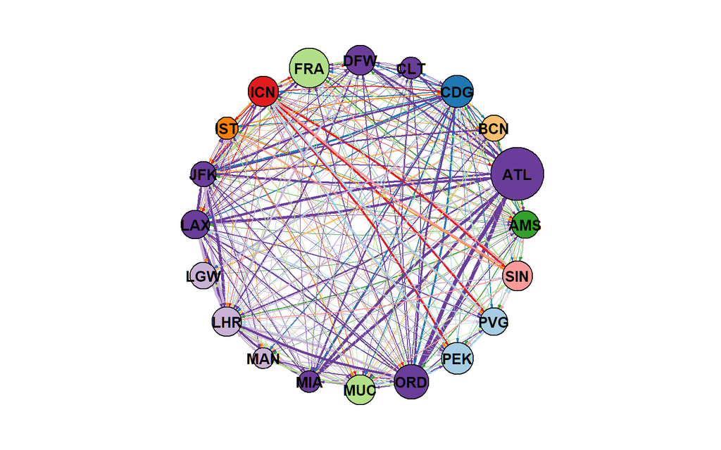

```r
V(g_top)$color <- as.factor(V(g_top)$country)
edge_starts <- ends(g_top, E(g_top), names=F)[,1] # Starting nodes for each edge
E(g_top)$color <- V(g_top)$color[edge_starts] # Match edge color to color of starting node

par(mar = c(1,1,1,1)) # Plot margins (to make plot fill more of page)
plot(g_top, edge.arrow.size=0.2, vertex.size=V(g_top)$strength / 64, vertex.shape='circle', vertex.label.cex=1, vertex.label.font=2, vertex.label.family='sans', vertex.label.color='black', edge.width = E(g_top)$weight / 5, edge.curved = 0.1, layout=layout.circle, palette=brewer.pal(n_distinct(V(g_top)$country), 'Paired'))
```

In the above graph, the size of the node is proportional to its total strength, i.e. the weighted sum of all edges flowing into and out of the node. The color of the node corresponds to the country of the airport. The width of the edge is proportional to the original `weight` we calculated earlier, i.e. the count of that city pair appearing in the `routesel` data file. Finally, the color of the edge matches the color of its starting node, to help visualize the directionality of the network.

One thing that stands out to me is the dominance of domestic US air travel, even in a global routes dataset. In particular, Atlanta (ATL) has by far the greatest strength; its connection to and from Chicago O’Hare (ORD) is likely a significant contributor, and dwarfs almost any other city pair in the top 20–including transcontinental, transatlantic, and intra-Europe/intra-Asia routes. I was also surprised at the German hubs of Frankfurt (FRA) and Munich (MUC)–their strength is quite high without any particularly dominant city-pairs; perhaps this is an indication of Germany’s high betweenness, i.e. high strength resulting from a large number of infrequently-traveled routes rather than a few major arterial connections.

#### Other Maps

Note that this graph only shows flights among the 20 airports with the greatest strength; it does not show other airports that the top 20 airports fly to. Suppose we were interested in visualizing that more complete map, i.e. we want to see the map of any routes that depart from or arrive in the airports with the highest strength:

```r
choose_top <- 5

top_subset <- top_degree_airports[0:choose_top,] # Further filter the top list from above
## Show the top_subset nodes, and any direct destination from those nodes (1-neighbors)
g_out <- subgraph.edges(g, unlist(incident_edges(g, top_subset$name, mode="out"), use.names=F))

v_attrs <- as_tibble(vertex_attr(g_out))
gorder(g_out) # Number of vertices
```

```
## [1] 652
```

```r
n_distinct(v_attrs$country) # Number of unique countries
```

```
## [1] 147
```

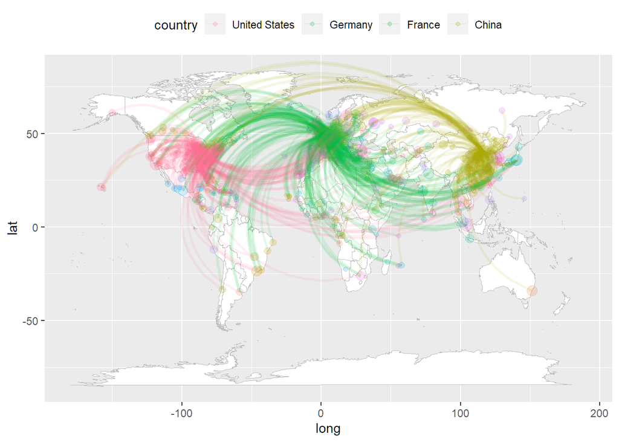

```r
world <- map_data("world")

ggplot() +
  geom_map(data=world, map=world, aes(long, lat, map_id=region), color='gray', fill='white', size=0.05) +
  geom_point(data=v_attrs, aes(x=longitude, y=latitude, size=strength/4096, color=country), alpha=0.2) +
  geom_curve(data=as_long_data_frame(g_out), aes(x=from_longitude, xend=to_longitude,
                               y=from_latitude, yend=to_latitude, color=factor(from_country), size=weight/4096),
                              alpha=0.1) +
  scale_color_discrete(breaks = top_subset$country) +
  scale_size(guide='none') +
  theme(legend.position="top")
```

So, by looking at just the 5 airports with the greatest total strength, we can fly *from* those airports to a total of 647 other airports, spread across 147 countries! Note that this is only showing the routes *departing* from the top 5 airports…a graph attempting to show arrivals as well would be pretty overwhelming.

Here’s what that would look like for just the top 2 airports, Frankfurt (FRA) and Atlanta (ATL):

```r
choose_top <- 2

top_subset <- top_degree_airports[0:choose_top,]
## Now show all departures and arrivals to/from top nodes (mode='all')
g_out <- subgraph.edges(g, unlist(incident_edges(g, top_subset$name, mode="all"), use.names=F))

v_attrs <- as_tibble(vertex_attr(g_out))
gorder(g_out)
```

```
## [1] 414
```

```r
n_distinct(v_attrs$country)
```

```
## [1] 116
```

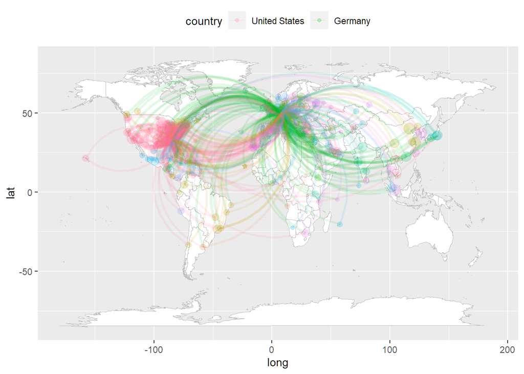

```r
ggplot() +
  geom_map(data=world, map=world, aes(long, lat, map_id=region), color='gray', fill='white', size=0.05) +
  geom_point(data=v_attrs, aes(x=longitude, y=latitude, size=strength/4096, color=country), alpha=0.2) +
  geom_curve(data=as_long_data_frame(g_out), aes(x=from_longitude, xend=to_longitude,
                               y=from_latitude, yend=to_latitude, color=factor(from_country), size=weight/4096),
                              alpha=0.1) +
  scale_color_discrete(breaks = top_subset$country) +
  scale_size(guide='none') +
  theme(legend.position="top")
```

We still see that those two airports are connected (via departures, arrivals, or both) to 412 other airports in a total of 116 countries!